# DigitalSkillsWS1920

### Teammitglieder

- Jill Koester
- Benasir Wapniarz
- Carlotta Hohne

### 1. Forschungsfrage

Inwiefern unterscheiden sich Studierende und Nicht-Studierende in der Ausprägung ihrer digitalen Fähigkeiten?

### 2. Faktorenraum

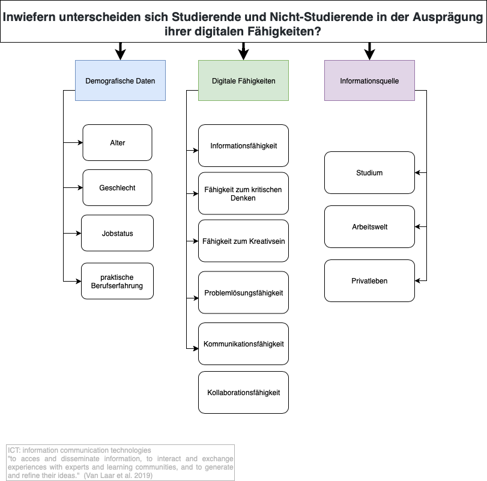

Faktorenraum

### 3. Faktoren

Aus dem Paper haben wir folgende Forschungsfrage entwickelt: Inwiefern unterscheiden sich Studierende und Nicht-Studierende in der Ausprägung ihrer digitalen Fähigkeiten?

Wir gehen davon aus, dass heutige Studierende im Laufe ihres Studiums stärker ausgeprägte digitale Fähigkeiten erlangen, als Nicht-Studierende in ihrem Berufs- und Privatleben und es aufgrund dessen zu einem Unterschied in der Ausprägung der digitalen Fähigkeiten Studierender und Nicht-Studierender kommt.

Es sollen zu folgenden Faktoren Items entwickelt werden, die aus dem Paper hervorgehen:

- Informationsfähigkeit
- Fähigkeit zum kritischen Denken
- Fähigkeit zum Kreativsein
- Problemlösungsfähigkeit
- Kommunikationsfähigkeit
- Kollaborationsfähigkeit

Alle Faktoren sind gleichermaßen relevant, da diese die Gesamtheit der digitalen Kompetenz bilden. Daneben haben wir auch die Einstellung gegenüber der Informations- und Kommunikationstechnik (ICT) erhoben.

### 4. Hypothesen

#### Hypothese 1: Es besteht ein Unterschied zwischen Studierenden und Nicht-Studierenden im Hinblick auf die Einstellung gegenüber ICTs.

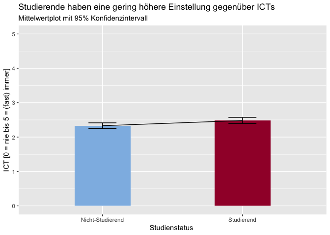

ICT

In der Stichprobe haben Studierende eine höhere ICT Einstellung als Nicht Studierende. Dieser Unterschied ist signifikant (F(6,392)=2.27, p < .037).

#### Hypothese 2: Es besteht ein Unterschied zwischen Studierenden und Nicht-Studierenden im Hinblick auf die Informationsfähigkeit.

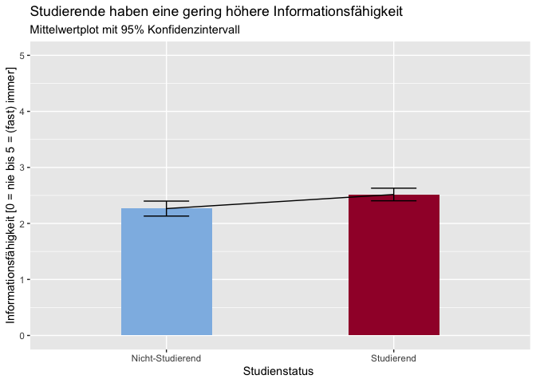

Informationsfähigkeit

#### Hypothese 3: Je älter eine Person ist, desto mehr sinkt seine Kommunikationsfähigkeit.

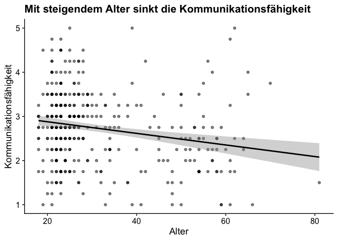

Kommunikationsfähigkeit

Es gibt einen signifikanten Zusammenhang zwischen Alter und Kommunikationsfähigkeit (τ = -0.208, p < .001). Das bedeutet, dass mit steigendem Alter die Kommunikationsfähigkeit sinkt.